# How Many People Follow a Member of Congress

Three platforms, one question, and three different Congresses

Democracy’s Data

Last updated September 13, 2026 at 10:53a EDT

A member of Congress’s follower count gets quoted like an election result. A representative with two million followers is described as a force. A senator with twenty thousand is described as quiet. The number is standing in for political weight, and it is worth asking whether it has earned the job.

Congress makes that checkable, because its hierarchy is a matter of public record. Which chamber a member sits in, how long they have been there, and what they chair are all published. Every member also has an audience anybody can count. Set the two beside each other and see whether they agree.

Counting the audience turns out to be the hard half. Nobody publishes the number.

## The test

The counts here were read off the screen, one profile at a time, on 2026-08-15. Every one of the 537 sitting members of Congress was looked for on 3 platforms: X, Instagram and Bluesky. That comes to 1,611 looks at a profile, misses included, and the reading is frozen at that date so the numbers in this text stay checkable.

Why read profile pages, when so much else about Congress arrives as a file? There is no file. The House does not keep one and neither does the Senate. The platforms know each number exactly and either sell access to it or do not sell it at all. X sells the exact count through its developer service: a subscription from $200 a month when these profiles were read, and by September 2026 a charge of about a cent for each profile looked up, either way behind a developer account;[^1] Instagram offers no equivalent a reader could use. Bluesky answers a public request with an exact count and asks for no account and no key (https://public.api.bsky.app).

So the number is taken the way any member of the public gets it. You open the profile signed out, and you write down what is on the screen.

A follower count is a platform’s own ledger, kept while the platform was doing something else. Nobody was measuring a politician’s standing when the row was written. A server was recording that an account had clicked a button, and the description of a politician is a by-product. The section introduction is about that whole family of records, and about what changes when a file describes people nobody set out to describe.

## The data

Deciding who counts as Congress comes first, and it is a decision a reader may argue with. The roster used here is unitedstates/congress-legislators (https://github.com/unitedstates/congress-legislators), a list of sitting members kept by volunteers rather than by either chamber. Its Congress is 537 people rather than 535, because it includes the 6 delegates who sit and speak and vote in committee but not on the floor. Neither figure is wrong. What is wrong is not saying which one you used.

Then the handles. You cannot ask a platform for the account belonging to the senator from Massachusetts. You can only ask about a handle, and no official body publishes the list. The same volunteer project keeps a crosswalk, a table that translates one list into another, here from a member to their accounts on X and Instagram. Bluesky is not in it at all, so those handles were guessed: take the member’s name and put it under their own chamber’s own domain, as in `schiff.senate.gov`.

That guess has a property worth pausing on. A handle ending in `senate.gov` can only exist if somebody who controls `senate.gov` put it there, because the platform checks the claim against the domain’s own records.[^2] A hit cannot be an impersonator, which is what **verified** means in this brief: verified by the chamber’s own web administrators, not by the platform. Search Bluesky by name instead and the top results for a well-known member include accounts whose own descriptions say *Parody* and *Satirical*.

Two cleaning decisions shape everything below. **Misses are recorded rather than dropped, and recorded by kind.** No handle known means the roster lists no account for that member. No account found means the member appears not to be on the platform. A third kind means the roster names a handle the platform does not have, which is a different failure from either.

**The counts are kept in the form the platform gives them.** X prints `11.5M` rather than a number, and no amount of tidying turns the first into the second.

Take one member with a count on all three. On 2026-08-15 the row for Schiff, Adam read 3.3M on X, 611,892 on Instagram and 234,655 on Bluesky. The X figure is rounded, and stands for every exact count that rounds to it; the other two are exact. Open the same three profiles today and none of the three will match, because followers arrive and leave every hour, and neither reading is wrong. A count is a fact about a day. That is why the date is part of the number, and why the tables below describe 2026-08-15 and are not refreshed.

`all_members.csv` therefore carries `state`, `chamber`, `member` and `party`, then one column per platform: `x`, `instagram` and `bluesky`, each holding either a count or the named reason there is none. `coverage.csv` carries `platform`, `members`, `handle_on_file`, `count_read`, the three miss columns and `pct_covered`. `party_coverage.csv` splits that coverage by party, and `platform_leaders.csv` names the most-followed member each platform knows about.

## What it says about democracy

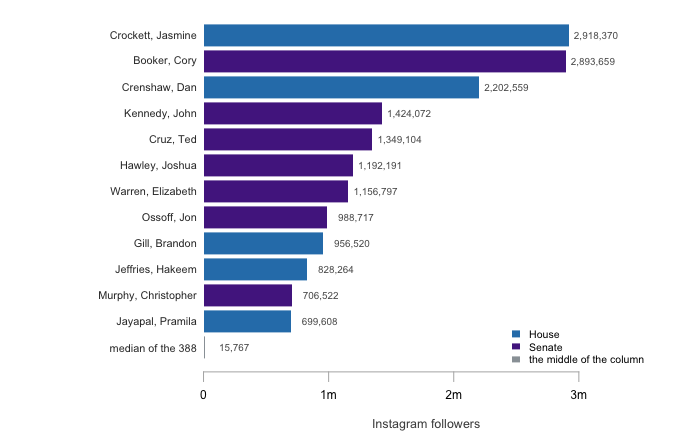

Hover a bar for the exact count.

**Figure 1. The twelve largest congressional accounts on Instagram, and the middle of the same column.** A ranked bar chart fits this question because the question is about shape: how far the top of a distribution stands above the ordinary case. The bottom bar is the median of the 388 members whose count was read, the member in the exact middle when all 388 are lined up by count, drawn on the same axis as the rest, and colour is the chamber the member sits in.

**The ten largest accounts hold 43.3% of all the followers in that column.** The bottom half of the same list holds 3.6%. The largest single account belongs to Crockett, Jasmine, with 185 times as many followers as the median member. Measured the way economists measure income inequality, with the Gini coefficient, the distribution scores 0.81 on a scale where 0 would mean every member had the same audience and 1 that one member had all of it.

Now set that shape against the institution. Office is not irrelevant. Senators are 19.3% of the members counted and 12 of the twenty-five largest accounts, and the median senator here has 50,751 followers against 10,550 for the median representative. The more powerful chamber does have the larger audiences.

The two most senior figures in the file are not in the file at all. Mike Johnson, the Speaker of the House, and John Thune, the Senate majority leader, both appear with handles on file that neither platform has, which is the third kind of miss. Their audiences may well be enormous. What is certain is that the roster is not tracking them, and nothing about their offices made it more likely to.

So the answer to the opening question is a qualified no. A follower count tracks the chamber a member sits in, loosely. It does not track anything finer, and the scale it works on belongs to fame rather than to office.

That last point is a fact about the file as much as about Congress, and it generalises. **Each platform describes a different Congress.**

| Platform | Members | Handle on file | Count read | No handle known | No account found | Handle wrong | % of Congress |
| --- | --- | --- | --- | --- | --- | --- | --- |
| X | 537 | 505 | 490 | 32 | 0 | 15 | 91.2 |
| Instagram | 537 | 407 | 388 | 130 | 0 | 19 | 72.3 |
| Bluesky | 537 | 135 | 135 | 0 | 402 | 0 | 25.1 |

Not one of them covers the whole institution. The best of them, X, gave a number for 490 of 537 members. 34 handles across the platforms are on file and wrong, and those are not scattered at random.

| Member | Party | Now sits in | Handle the roster still lists |
| --- | --- | --- | --- |
| Elissa Slotkin | Democrat | Senate | RepSlotkin |
| Jacky Rosen | Democrat | Senate | repjackyrosen |
| Jim Banks | Republican | Senate | RepJimBanks |
| Jim Banks | Republican | Senate | repjimbanks |
| John Curtis | Republican | Senate | RepJohnCurtis |
| John Curtis | Republican | Senate | repjohncurtis |

**11 of them belong to a member who was promoted.** They moved from the House to the Senate, renamed the account to match the new job, and the roster went on pointing at the old name. A hand-maintained list decays fastest around the people whose careers move fastest, which leaves it least reliable about the members most likely to be studied.

The sorting can be far larger than that.

| Party | Members of Congress | Found on Bluesky | % |
| --- | --- | --- | --- |
| Democrat | 260 | 134 | 51.5 |
| Independent | 3 | 1 | 33.3 |
| Republican | 274 | 0 | 0.0 |

134 Democrats have a verified Bluesky account under their own chamber’s domain, 51.5% of the party. Republicans have 0, out of 274. This is not a flaw in the collection and not a quirk of the guessing rule, which builds the same candidate handles from a Republican’s name as from a Democrat’s. The rule found no Republicans because there are almost none to find.

| Party | Members of Congress | Found on X | % |
| --- | --- | --- | --- |
| Republican | 274 | 246 | 89.8 |
| Democrat | 260 | 241 | 92.7 |
| Independent | 3 | 3 | 100.0 |

X covers Republicans at 89.8% and Democrats at 92.7%. The chamber did not change between these two tables. **The instrument did.** A sentence like *the median member of Congress has N followers* is therefore a different sentence on each platform, and on Bluesky it is a claim about Democrats wearing the word Congress.

| Platform | Most followed member | Party | Followers | Members covered |
| --- | --- | --- | --- | --- |
| Bluesky | Bernard Sanders | Independent | 572,693 | 135 |
| Instagram | Jasmine Crockett | Democrat | 2,918,370 | 388 |
| X | Bernard Sanders | Independent | 11.5M | 490 |

The platforms cannot even agree on who is first. Between them they name 2 different people as the most-followed member of Congress, and each is correct about its own slice. The last column is the reason: no two of them hold the same part of the institution.

### Every member, every platform

Congress is small enough to print whole, so here it is: all 537 members, sorted by state with senators first. Find your own delegation and check it against the profiles.

Where there is no number, the reason is named rather than left blank, because a blank reads as zero and none of these are zero. **no handle** means no account is listed for that member on that platform. **handle wrong** means an account is listed and the platform does not have it. A dash means nothing answered under the member’s own chamber domain.

| State | Chamber | Member | Party | X | Instagram | Bluesky |
| --- | --- | --- | --- | --- | --- | --- |
| AK | Senate | Murkowski, Lisa | R | 337.4K | 33,425 | — |
| AK | Senate | Sullivan, Dan | R | 76K | 18,950 | — |
| AK | House | Begich, Nicholas | R | 10.1K | 1,315 | — |
| AL | Senate | Britt, Katie | R | 133.2K | 108,404 | — |
| AL | Senate | Tuberville, Tommy | R | 166.7K | 38,229 | — |
| AL | House | Aderholt, Robert | R | 40.2K | no handle | — |
| AL | House | Figures, Shomari | D | 1,766 | 6,808 | — |
| AL | House | Moore, Barry | R | 25.9K | no handle | — |
| AL | House | Palmer, Gary | R | 30.6K | 4,842 | — |
| AL | House | Rogers, Mike | R | 55.1K | 5,879 | — |
| AL | House | Sewell, Terri | D | 53.6K | 43,867 | 1,993 |
| AL | House | Strong, Dale | R | 9,941 | 5,277 | — |
| AR | Senate | Boozman, John | R | 116.3K | 17,298 | — |
| AR | Senate | Cotton, Tom | R | 821.9K | no handle | — |
| AR | House | Crawford, Eric | R | 34.2K | 3,817 | — |
| AR | House | Hill, J. | R | 38.6K | 9,250 | — |
| AR | House | Westerman, Bruce | R | 17.9K | no handle | — |
| AR | House | Womack, Steve | R | 34.8K | 9,502 | — |
| AS | House | Radewagen, Aumua Amata | R | 4,706 | no handle | — |
| AZ | Senate | Gallego, Ruben | D | handle wrong | handle wrong | 32,993 |
| AZ | Senate | Kelly, Mark | D | 286.4K | 553,777 | — |
| AZ | House | Ansari, Yassamin | D | 67.3K | 188,266 | — |
| AZ | House | Biggs, Andy | R | 1.1M | 24,562 | — |
| AZ | House | Ciscomani, Juan | R | 12.7K | 4,902 | — |
| AZ | House | Crane, Eli | R | 162.8K | no handle | — |
| AZ | House | Gosar, Paul | R | 386.8K | 18,414 | — |
| AZ | House | Grijalva, Adelita | D | no handle | no handle | — |
| AZ | House | Hamadeh, Abraham | R | no handle | no handle | — |
| AZ | House | Schweikert, David | R | 39.9K | 8,914 | — |
| AZ | House | Stanton, Greg | D | 23.4K | 13,135 | — |

[output cut: 507 more lines]

## What this brief cannot tell you

**It cannot rank Congress by followers.** No platform here supports that sentence. Bluesky is missing a party, Instagram is missing about a quarter of the members, and the largest counts on X arrive as `11.5M`.

**It cannot tell you these are constituents, or voters, or even people.** A follower is an account that clicked a button, possibly years ago, possibly from another country, possibly automated, a **bot**, an account run by software rather than by a person. Nothing here separates an engaged voter in the member’s district from a dormant account in another hemisphere.

**It cannot tell you anyone is reading.** A follower count measures an audience that accumulated, not one that showed up. Attention paid on a particular day is a different quantity, and it needs a different file.

**It is one day.** 2026-08-15, frozen on purpose. Every count has moved since, and a fresh collection would be a new measurement rather than a check on this one.

**It cannot tell you why the party gap exists.** The brief establishes that Bluesky’s congressional population is one party. Whether that is about when the platform grew, who left X and when, or a staffing decision repeated office by office, is not in this file.

## What you should have learned

- Follower counts are distributed far more unequally than congressional power is: the ten largest accounts hold 43.3% of all Instagram followers in this file, and the bottom half of the members hold 3.6%.
- Office tracks the audience loosely and not finely: the median senator counted here has 50,751 followers against 10,550 for the median representative, but the largest account of all belongs to a member of the House, and neither the Speaker nor the Senate majority leader has a usable row in the file.
- Coverage is a finding, not a nuisance. No platform describes the whole institution, and the best of them reaches 91.2% of the 537 members.
- One platform is missing a party: 0 of 274 Republicans are on Bluesky under their own chamber’s domain, against 51.5% of Democrats. Any average taken there is an average of one side.
- A list of handles kept by hand goes wrong fastest about the people whose jobs change, which is why 11 of the 34 wrong handles belong to members who were promoted.

## Extensions

- `all_members.csv` gives an exact `instagram` count for most members alongside `chamber`. Sort by the count, then compare the House rows against the Senate rows. Does the more powerful chamber have the larger audiences all the way down, or only in the middle?
- `all_members.csv` also carries `state` and `party`. Group the counts by party and take a median for each. Is the gap between the parties larger or smaller than the gap between the chambers?
- `coverage.csv` gives `pct_covered` for each platform, with the reasons for the misses broken out in `no_handle`, `no_account` and `other_miss`. Which platform gives the most complete picture of Congress, and which kind of miss does each one suffer from?
- `party_coverage.csv` splits coverage by party in the `pct` column. Find the platform where one party is barely present, then ask what you would have concluded from its median without checking.
- `platform_leaders.csv` names the most-followed member on each platform in `member`, with `covered` beside it. They differ. What is a follower count actually measuring?
- **Stretch.** Bluesky’s public interface is free and needs no key. Re-collect the Bluesky column today and set it against `bluesky` in `all_members.csv`. How much does a year move a follower count, and does it move every member the same way?
- **Stretch.** Roll-call records say how often a member votes with their party, and committee rosters say who chairs what. Join either to `all_members.csv` and ask whether a large audience predicts anything at all about how a member behaves inside the building.

## Sources

**Data**

**Follower counts.** Read from public profile pages on 2026-08-15, signed out, one profile at a time. That reading is frozen at that date; the tables above describe that day and are not refreshed.

- X — `https://x.com/<handle>`. Rounded counts only. The developer service that would give exact counts was priced from $200 a month when the profiles were read: https://developer.x.com/en/products/x-api. That page no longer resolved when last checked; the current price list is at https://docs.x.com/x-api/getting-started/pricing.
- Instagram — `https://www.instagram.com/<handle>/`. A rounded count on the screen, a fuller one carried in the page.
- Bluesky — the free public interface at https://public.api.bsky.app/xrpc/app.bsky.actor.getProfiles. No key, no account. Exact counts.

**Who is in Congress, and their handles.** unitedstates/congress-legislators, current members and the social-media crosswalk, as published on 2026-08-15: https://unitedstates.github.io/congress-legislators/legislators-current.csv and the `legislators-social-media.json` beside it. The project’s home page, https://unitedstates.github.io/congress-legislators/, no longer resolved when last checked; the project lives at https://github.com/unitedstates/congress-legislators. Both files are used as published. - Bluesky’s domain handles, and why a `senate.gov` handle cannot be faked: https://bsky.social/about/blog/4-28-2023-domain-handle-tutorial

**The data itself**

Every figure above is drawn from these tables. They are plain CSV, they open in a spreadsheet, and they are yours to take further.

`all_members.csv`, `coverage.csv`, `party_coverage.csv`, `platform_leaders.csv`, `stale_handles.csv`

Two more files here are not data about the subject at all – they are how this chapter checked its own work: `facts.csv`, the individual numbers the text above quotes, and `checks.csv`, the arithmetic verified before anything was drawn.

| Check | Result |
| --- | --- |
| every member was looked for on every platform | TRUE |
| no platform covers the whole chamber | TRUE |
| coverage differs between platforms rather than being one wall | TRUE |
| the Bluesky gap is a party gap, not a size gap | TRUE |
| X covers both parties at rates within 25 points of each other | TRUE |
| a wrong handle is a different failure from a missing one | TRUE |
| stale handles concentrate among members whose job changed | TRUE |
| the exact number harvested is the follower count and not another field | TRUE |
| the full member table agrees with the coverage table, platform by platform | TRUE |
| the platforms do not agree on one answer | TRUE |

Why this data cannot be fetched again

```
The dataset behind this page comes from a source you cannot download
today, and no assistant can download it for you.

WHY NOT. The numbers are follower counts — X, Instagram and Bluesky —
for all 537 sitting members of Congress, read once on 15 August 2026.
There is no file to download: no platform publishes a list of
congressional follower counts. X sells the API that would answer the
question for $200 a month, and its old free endpoint now returns an
empty page. So the numbers were taken the way a person gets them: a
logged-out browser loaded each public profile, about 900 page loads
over half an hour, and wrote down the number on the screen. Follower
counts move by the minute. The snapshot cannot be reproduced, only
re-taken, and a re-take is a different measurement of a different day.

WHAT EXISTS INSTEAD. One of the three platforms is genuinely open:
Bluesky has a free public API with no key and no account
(public.api.bsky.app), and an assistant can query it for you today.
The handles must come from somewhere else — a volunteer-maintained
roster called unitedstates/congress-legislators covers X and
Instagram, and congressional Bluesky handles can be guessed against
senate.gov and house.gov, domains only the chambers control, so a hit
cannot be the wrong person. A fresh collection built that way is not a
check on this one; it is a new, equally valid snapshot of a moving
number.

WHAT YOU CAN STILL CHECK. These numbers say whether you are holding
the same snapshot this book describes:
- 537 members, asked about on three platforms: 1,611 rows, misses
  included
- X yielded a count for 490 members, Instagram for 388, Bluesky
  for 135
- of the 135 on Bluesky, 134 are Democrats and none are Republicans
```

[^1]: X Developer Platform, “Pricing,” https://docs.x.com/x-api/getting-started/pricing. The product page cited when the profiles were read, https://developer.x.com/en/products/x-api, no longer resolved when last checked.
[^2]: Bluesky lets any web domain serve as an account’s handle, and confirms the claim against a record the domain’s owner must publish: “How to set your domain as your handle,” Bluesky, 28 April 2023, https://bsky.social/about/blog/4-28-2023-domain-handle-tutorial.